# Internation Economics Project 1

Author

Sam Adams

Published

January 1, 2023

## Introduction

Argentina is a South American country known for its vast geographical area, spanning approximately 2.78 million square kilometers, making it the eighth-largest country in the world. As of my last knowledge update in September 2021, Argentina had a population of around 45 million people, and its per capita income or GDP (Gross Domestic Product) was approximately $10,500 to $11,000 USD.

## General Description

Argentina operates as a federal presidential republic with a multi-party system. The country’s political landscape is characterized by a separation of powers among the executive, legislative, and judicial branches. The President of Argentina serves as both the head of state and the head of government and is elected by popular vote for a four-year term, with the possibility of one re-election. The National Congress, a bicameral legislature, consists of the Chamber of Deputies and the Senate. Members of the Chamber of Deputies are elected every two years, while Senators serve six-year terms. Argentina’s political institutions also include provincial governments with their own governors, legislatures, and constitutions, reflecting a federal structure.

The country has a diverse political landscape with several political parties, the most prominent being the Peronist movement, which includes various factions. Other significant parties include the Radical Civic Union (UCR), PRO (Republican Proposal), and left-wing parties like the Workers’ Party (Partido de los Trabajadores) and the Broad Front (Frente Amplio). Political ideologies range from center-left to center-right and encompass a wide spectrum of beliefs and policy positions. Argentina’s political history has been marked by periods of authoritarian rule and democratic transitions, with the country currently under a democratic system since the early 1980s. The judiciary, while separate from the executive and legislative branches, has played a vital role in upholding the rule of law and protecting civil liberties in Argentina, particularly during periods of political upheaval.

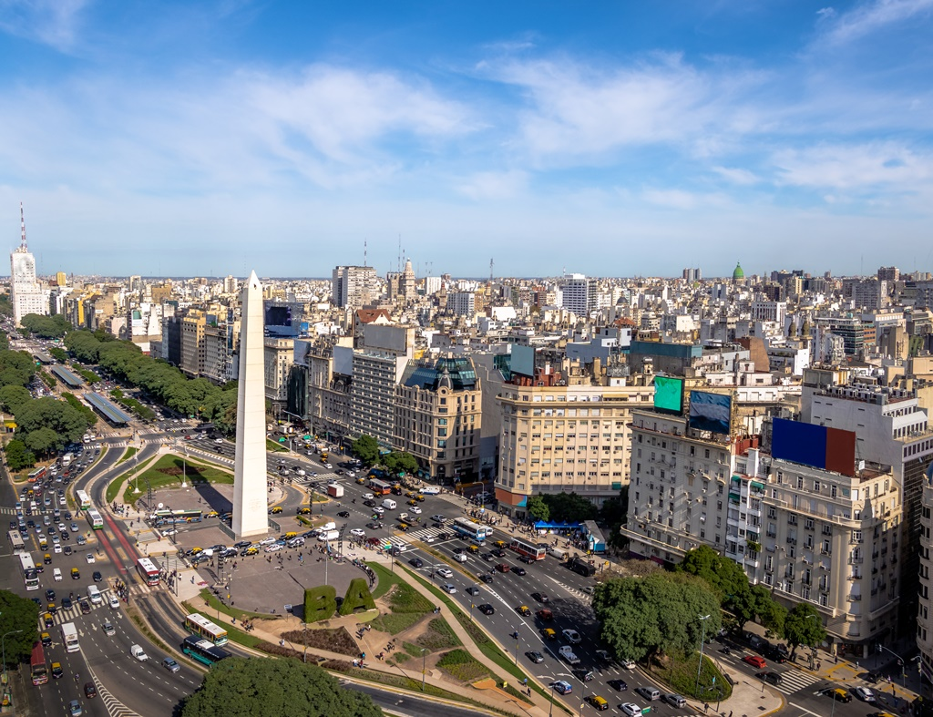

*Buenos Aires arial view*

## History

Argentina’s economic history has been marked by cycles of growth and crisis, reflecting a mix of both promise and challenges. During the late 19th and early 20th centuries, Argentina experienced significant economic expansion, driven by its agricultural exports, particularly beef and wheat, which earned it the moniker “The Breadbasket of the World.” However, economic prosperity was often followed by periods of instability, such as the Great Depression, which hit Argentina hard, leading to political and economic turmoil.

The mid-20th century saw a series of populist governments, notably under Juan Domingo Perón, who implemented extensive social welfare policies. While these policies brought social benefits, they also led to fiscal deficits and inflation. The late 20th century and early 21st century witnessed a roller-coaster of economic events, including hyperinflation in the late 1980s, economic liberalization in the 1990s, and a severe economic crisis in the early 2000s, marked by a massive sovereign debt default and currency devaluation. Argentina’s economy has struggled with high inflation, fiscal deficits, and external debt challenges in recent decades, and the government has implemented various economic policies to stabilize the situation, which has had mixed success. Economic history has played a significant role in shaping Argentina’s political landscape, with periodic shifts between interventionist and market-oriented policies, and it remains a central issue in the country’s political discourse.

[figure not shown]

*Argentina Default [Source](https://www.ft.com/content/6134a049-0daa-427f-9ce4-ec26ff22826d)*

## Major Trading Partners

Top 5 Exporting Partners (Share of Total Exports):

```
1. Brazil - Approximately 15-20%
2. China - Approximately 10-15%
3. United States - Approximately 8-10%
4. Chile - Approximately 5-8%
5. Netherlands - Approximately 4-7%
```

Top 5 Importing Partners (Share of Total Imports):

```
1. China - Approximately 15-20%
2. United States - Approximately 10-15%
3. Brazil - Approximately 8-12%
4. Germany - Approximately 5-8%
5. Mexico - Approximately 4-7%
```

## Major Import & Exports

Major Exports:

```
1. Soybeans and Soybean Products - including soybean oil and meal.
2. Beef and Beef Products - Argentina is known for its high-quality beef.
3. Corn - Argentina is a significant corn producer and exporter.
4. Wheat - Wheat and wheat products are important exports.
5. Motor Vehicles and Parts - Including automobiles and auto parts.
```

Major Imports:

```
1. Machinery and Equipment - Including industrial machinery and electrical machinery.
2. Petroleum and Petroleum Products - Argentina imports petroleum due to domestic production shortfalls.
3. Electronics - Such as computers, smartphones, and consumer electronics.
4. Chemical Products - Including chemicals for industry and agriculture.
5. Pharmaceuticals - Medications and medical supplies.
```

## Emperical Model

Gravity Model

$$Tij = A × Yi × Yj/Dij$$

*Where A is a constant term, Tij is the value of trade between country I and country j, Yi is country i’s GDP and Yj is country j’s GDP, and Dij is the distance between the two countries.*

$$Ln(X_{ij,t}) = β_0 + β_1(ln GDPI_{t}) + β_2(ln GDP_{j,t}) + β_3(ln Dist_{ij}) + β_4(ln Pop{it}) + β_5(ln Pop{jt}) + ε_{ij,t}$$

All variables are expressed in natural logarithmic form, a transformation employed to linearize any inherent non-linearity in the data. Within this context, “GDP I” represents Argentina’s domestic Gross Domestic Product (GDP), while “GDP J” refers to the corresponding GDP of its trading partner in a given year. “Distance” signifies the harmonic distance, a crucial concept in graph theory and network analysis, utilized to assess the proximity and similarity between nodes in a network. This metric takes into careful consideration not only the sheer number of connections between nodes but also the quality of these connections.

Harmonic distance proves particularly valuable in scenarios where relationships between nodes extend beyond binary connectivity (i.e., either connected or not connected), encompassing nuanced attributes such as connection weights and strengths. It outperforms the standard distance metric between capitals in capturing the intricate web of relationships in complex networks.

“Pop I” characterizes the domestic population of Argentina, while “Pop J” signifies the population of the foreign trading partner. Finally, the “error term” serves as an essential component, encapsulating any unknown noise or unaccounted variables within the model.

$$Ln(X_{ij}) = β_0 + β_1(ln GDPI_{t}) + β_2(ln GDP_{j,t}) + β_3(ln Dist_{ij}) + β_4(ln Pop{it}) + β_5(ln Pop{jt}) + β_6(Lang_{ij}) + β_7(After Def{ij}) ε_{ij,t}$$

This model incorporates several variables from the previous one, but it also introduces some notable distinctions. Notably, two dummy variables have been added to the model.

The first is “Lang,” a binary variable that assumes a value of 1 when Argentina and its trading partner share a common language. For instance, Spain and Argentina would have a “Lang” value of 1 if they share a language.

The second variable, “After Def,” is also a binary variable, taking on a value of 1 after the year 2001 when Argentina went into default and 0 prior to that year. These new variables provide additional dimensions for a more comprehensive analysis of the model.

In 2001, Argentina faced a devastating economic crisis driven primarily by its unsustainable debt burden and a rigid currency peg to the U.S. dollar. The country had accumulated a significant amount of external debt, mainly in the form of U.S. dollar-denominated bonds. This debt became increasingly unmanageable as Argentina’s economy suffered from a prolonged recession, high unemployment, and a shrinking GDP. The government’s decision to peg the Argentine peso to the U.S. dollar exacerbated the problem by making its exports less competitive and further constraining its ability to repay the dollar-denominated debt. In a desperate attempt to stabilize the situation, the International Monetary Fund (IMF) provided loans to Argentina, but the harsh austerity measures and conditions attached to the loans led to social unrest and economic contraction. On December 23, 2001, Argentina defaulted on its external debt, marking the largest sovereign debt default in history at the time. This default triggered a series of events, including the devaluation of the peso, bank freezes, and widespread social unrest.

The consequences of the 2001 Argentine economic crisis were profound and long-lasting. The default and devaluation led to a severe loss of savings for many Argentinians who had their deposits frozen in banks. The crisis also resulted in numerous changes in government leadership, further destabilizing the country’s political landscape. In the years that followed, Argentina engaged in complex negotiations with its creditors to restructure its debt, ultimately agreeing to significant debt write-downs. The crisis had a lasting impact on the country’s economy, with Argentinians facing high inflation and economic uncertainty for years. It also eroded trust in the country’s financial institutions and had a lasting effect on Argentina’s economic and political trajectory in the following decades.

```r
library(data.table)
library(ggplot2)
library(knitr)
library(kableExtra)
library(reshape2)
```

```r
load("data.RData")
data <- data.table(data)
df <- data[, .(ln_tradeflow = log(tradeflow_imf_d),
               ln_gdp_domestic = log(gdp_o),
               ln_gdp_foreign = log(gdp_d),
               ln_dist = log(distw_harmonic),
               ln_pop_domestic = log(pop_d),
               ln_pop_foreign = log(pop_o),
               common_language = comlang_off,
               after_default = ifelse(year > 2001, 1, 0))
         ]
df <- na.omit(df)
head <- head(df) %>%
        kable("html") %>%
        kable_styling(full_width = FALSE)
head
```

| ln_tradeflow | ln_gdp_domestic | ln_gdp_foreign | ln_dist | ln_pop_domestic | ln_pop_foreign | common_language | after_default |
| --- | --- | --- | --- | --- | --- | --- | --- |
| 7.854401 | 19.56034 | 14.09365 | 8.550047 | 4.386093 | 10.45833 | 1 | 0 |
| 7.884301 | 19.61361 | 14.13751 | 8.550047 | 4.421187 | 10.47062 | 1 | 0 |
| 7.827750 | 19.68695 | 14.24198 | 8.550047 | 4.447896 | 10.48265 | 1 | 0 |
| 7.867573 | 19.70752 | 14.32555 | 8.550047 | 4.469075 | 10.49431 | 1 | 0 |
| 8.021732 | 19.65455 | 14.35946 | 8.550047 | 4.488681 | 10.50547 | 1 | 0 |
| 8.374696 | 19.65695 | 14.44329 | 8.548692 | 4.509298 | 10.51605 | 1 | 0 |

## Examining the Gravity Model

The gravity model is an economic concept used to describe and predict the flow of goods, services, or people between two places, such as countries, cities, or regions. It’s named after the law of gravity because it’s based on the idea that there is a strong relationship between the size (usually measured by economic activity or population) of two places and the amount of interaction or exchange that occurs between them.

In simple terms, the gravity model suggests that the more significant and economically active two places are and the closer they are to each other, the more likely they are to engage in trade, travel, or other interactions. It’s often expressed as a mathematical equation, where the flow of trade, migration, or other interactions is directly proportional to the size of the two places (usually measured by their economic activity or population) and inversely proportional to the distance between them.

In essence, the gravity model helps economists and researchers understand and quantify the factors that influence the movement of goods, people, or services between different locations, making it a valuable tool for analyzing trade patterns, migration, and various economic activities.

## Distribution of Data

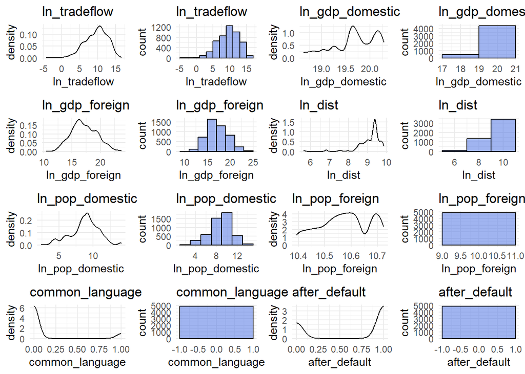

```r
plots_list <- list()

for (col in names(df)) {
  # Create a density plot
  density_plot <- ggplot(df, aes(x = !!sym(col))) +
    geom_density() +
    labs(title = col) +
    theme_minimal()

  # Create a histogram
  histogram_plot <- ggplot(df, aes(x = !!sym(col))) +
    geom_histogram(binwidth = 2, fill = "royalblue", color = "black", alpha = 0.5) +
    labs(title = col) +
    theme_minimal()

  # Combine the density plot and histogram using cowplot
  combined_plot <- cowplot::plot_grid(density_plot, histogram_plot, ncol = 2)

  # Add the combined plot to the list
  plots_list[[col]] <- combined_plot
}

# Arrange and display the plots in a grid
multiplot <- cowplot::plot_grid(plotlist = plots_list, ncol = 2, nrow = 4)
multiplot
```

Analyzing histograms and kernel density functions for each field yields valuable insights into the data’s distribution and characteristics. Notably, the population of foreign countries exhibits a bimodal distribution. This bimodality is easily explained, given that many nations have either small or large populations, with relatively few falling in the intermediate range.

Additionally, it’s apparent that dummy variables such as “common language” and “after default” do not conform to a unimodal distribution or any specific distribution akin to a normal curve.

## Correlation

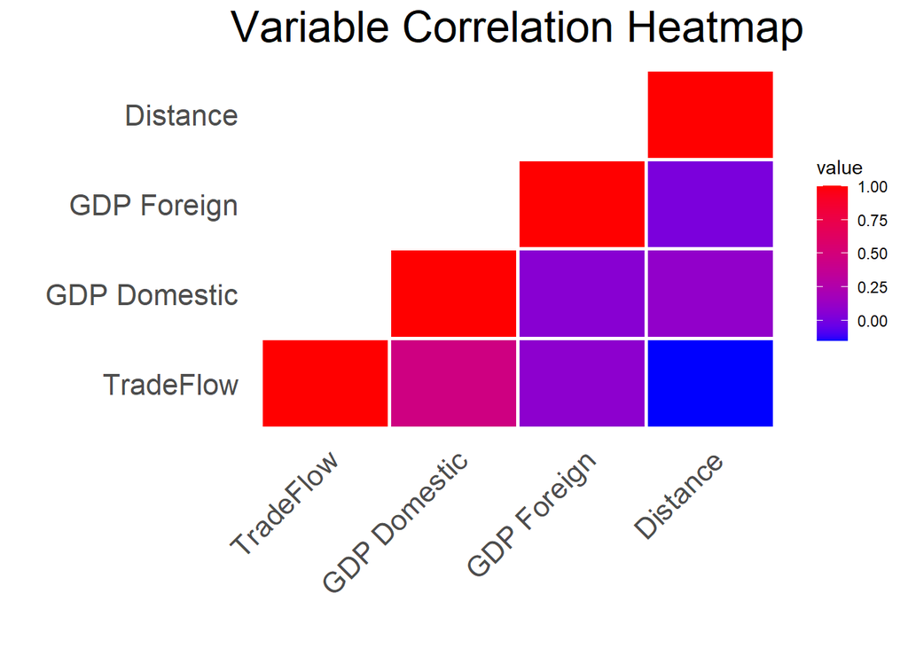

```r
cor_data <- as.data.frame(na.omit(data))
cols <- c("tradeflow_imf_d", "gdp_d", "gdp_o", "distw_harmonic")
cor_matrix <- cor(cor_data[, cols])
fancy_cols <- c("TradeFlow", "GDP Domestic", "GDP Foreign", "Distance")
rownames(cor_matrix) <- colnames(cor_matrix) <- fancy_cols
melted_cor <- melt(cor_matrix)

# Subset the lower triangle of the correlation matrix
cor_matrix_lower <- cor_matrix
cor_matrix_lower[upper.tri(cor_matrix)] <- NA

# Create the heatmap with a half triangle
ggplot(melt(cor_matrix_lower, na.rm = TRUE), aes(Var1, Var2, fill = value)) +
  geom_tile(color = "white", linewidth = 1) +
  scale_fill_gradient(low = "blue", high = "red") +
  theme_minimal() +
  theme(
    axis.text.x = element_text(angle = 45, hjust = 1, size = 16),
    axis.text.y = element_text(size = 16),
    axis.title = element_text(size = 18),
    plot.title = element_text(size = 24, hjust = 0.5),
    axis.ticks = element_blank(),
    panel.grid = element_blank()
  ) +
  labs(title = "Variable Correlation Heatmap", x="", y="")
```

## Tradeflow and GDP Relationships

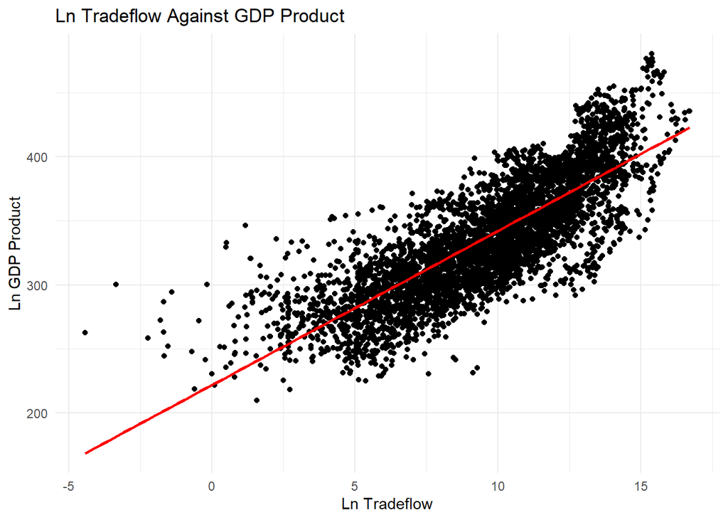

```r
ggplot(df, aes(x = df$ln_tradeflow, y = (df$ln_gdp_domestic * df$ln_gdp_foreign))) +
  geom_point() +
  geom_smooth(method = "lm", se = FALSE, color='red') +
  ggtitle('Ln Tradeflow Against GDP Product') +
  xlab('Ln Tradeflow') +
  ylab('Ln GDP Product') +
  theme(
    plot.title = element_text(size = 20),  # Increase title font size
    axis.title = element_text(size = 14)   # Increase axis label font size
  ) +
  theme_minimal()
```

**Economic Theory:** According to economic theory, the level of international trade is influenced by the economic activity of countries. The natural logarithm of GDP is used to account for the diminishing returns of economic activity, making it a better measure of economic size. As GDP grows, so does the potential for international trade, which is why there is a positive relationship.

**Market Size and Demand:** Larger economies tend to have a larger domestic market and more resources to invest in international trade. This leads to increased demand for imports and exports, resulting in a positive correlation.

**Economic Interdependence:** In a globalized world, economies are increasingly interdependent. Economic growth in one country can stimulate trade with other countries. As domestic and foreign economies grow, the potential for trade increases, resulting in a positive correlation.

**Statistical Relationship:** Taking the natural logarithm of the variables is a common statistical technique used to linearize the relationship between economic variables. When these variables follow exponential growth, their natural logarithms can result in a more linear and interpretable relationship.

## Emperical Model 1

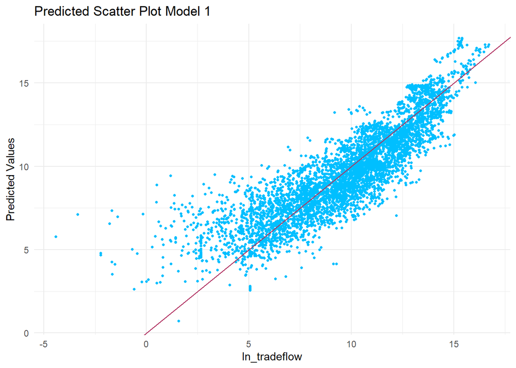

```r
# Fit the linear regression model
formula <- ln_tradeflow ~ ln_gdp_foreign + ln_gdp_domestic + ln_dist + ln_pop_domestic + ln_pop_foreign
model1 <- lm(formula, data = df)

# Get the predicted values from the model
predicted <- predict(model1)

# Create a data frame for the plot
plot_data <- data.frame(ln_tradeflow = df$ln_tradeflow, predicted = predicted)

# Create the scatter plot with ggplot2
ggplot(plot_data, aes(x = ln_tradeflow, y = predicted)) +
  geom_point(shape = 20, color = "deepskyblue") +
  labs(x = "ln_tradeflow", y = "Predicted Values",
       title = "Predicted Scatter Plot Model 1") +
  geom_abline(intercept = 0, slope = 1, color = "maroon") +
  theme_minimal()
```

Analyzing the forecasted values reveals a predominantly positive correlation between the model and the predicted outcomes.

## Emperical Model 2

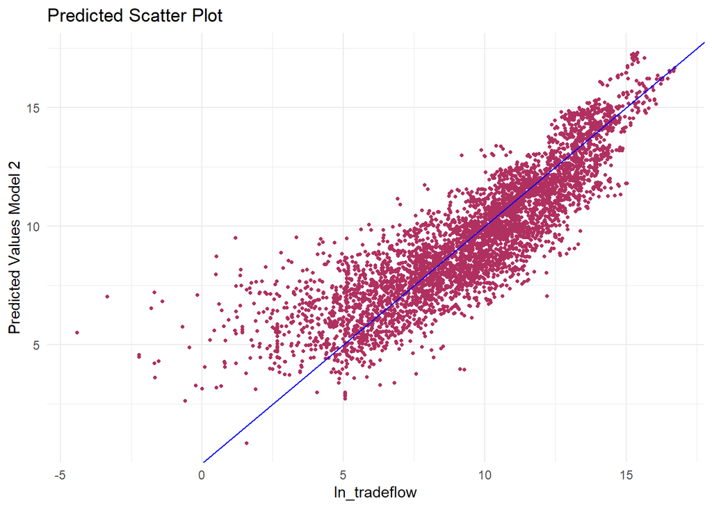

```r
# Fit the linear regression model
formula <- ln_tradeflow ~ ln_gdp_foreign + ln_gdp_domestic + ln_dist + ln_pop_domestic + ln_pop_foreign + common_language + after_default + 1
model2 <- lm(formula, data = df)

# Get the predicted values from the model
predicted <- predict(model2)

# Create a data frame for the plot
plot_data <- data.frame(ln_tradeflow = df$ln_tradeflow, predicted = predicted)

# Create the scatter plot with ggplot2
ggplot(plot_data, aes(x = ln_tradeflow, y = predicted)) +
  geom_point(shape = 20, color = "maroon") +
  labs(x = "ln_tradeflow", y = "Predicted Values Model 2",
       title = "Predicted Scatter Plot") +
  geom_abline(intercept = 0, slope = 1, color = "blue") +
  theme_minimal()
```

The same applies to this graphical representation.

## Pooled Model Statistics

```r
print(summary(model1))
```

```
Call:
lm(formula = formula, data = df)

Residuals:
     Min       1Q   Median       3Q      Max
-10.4698  -0.8328   0.1517   1.0070   5.1445

Coefficients:
                Estimate Std. Error t value Pr(>|t|)
(Intercept)      2.52457    2.81324   0.897    0.370
ln_gdp_foreign   1.11226    0.01516  73.362   <2e-16 ***
ln_gdp_domestic -0.02096    0.06870  -0.305    0.760
ln_dist         -1.43425    0.04004 -35.816   <2e-16 ***
ln_pop_domestic  0.15113    0.01662   9.094   <2e-16 ***
ln_pop_foreign   0.01879    0.33476   0.056    0.955
---
Signif. codes:  0 '***' 0.001 '**' 0.01 '*' 0.05 '.' 0.1 ' ' 1

Residual standard error: 1.56 on 4821 degrees of freedom
Multiple R-squared:  0.7493,    Adjusted R-squared:  0.749
F-statistic:  2882 on 5 and 4821 DF,  p-value: < 2.2e-16
```

Both the Adjusted R-squared and the F-statistic serve as valuable metrics for assessing data fitness. In the context of ANOVA, a significant F-statistic indicates statistically significant differences between the group means under comparison. The Adjusted R-squared, also known as the coefficient of determination, measures the goodness of fit of a regression model to the observed data and ranges from 0 to 1, with higher values reflecting a better model-data fit. In this case, an R-squared score of 0.749 is considered acceptable. The F-statistic in the provided output consists of two components: the numerator degrees of freedom (DF1) and the denominator degrees of freedom (DF2). In this specific case, the F-statistic is 2882, associated with 5 and 4821 degrees of freedom.

In the gravity model, the variable `ln_dist` plays a highly significant role with an impressively low p-value of 2e-16. This variable accounts for a considerable portion of the variation in ln tradeflow, along with `ln_gdp_foreign`, which also exhibits a p-value of 2e-16. Notably, `ln_dist` yields a negative beta coefficient, indicating that the farther a country is from its home country, the more likely bilateral tradeflow is inversely influenced by distance. For instance, a nation like Argentina, heavily reliant on maritime exports, would benefit from shorter shipping distances and increased traffic to boost domestic GDP.

Another robust predictor in the model is `ln_pop_domestic`, boasting a similarly striking p-value of 2e-16. The significance of this variable is evident on multiple fronts. Population often serves as the natural wellspring of domestic GDP growth and can be a pivotal factor contributing to a country’s economic advancement.

```r
print(summary(model2))
```

```
Call:
lm(formula = formula, data = df)

Residuals:
     Min       1Q   Median       3Q      Max
-10.3926  -0.8040   0.0904   0.9807   5.3204

Coefficients:
                Estimate Std. Error t value Pr(>|t|)
(Intercept)     13.34925    5.48983   2.432  0.01507 *
ln_gdp_foreign   1.09215    0.01505  72.550  < 2e-16 ***
ln_gdp_domestic  0.12557    0.08099   1.550  0.12110
ln_dist         -1.09132    0.04985 -21.894  < 2e-16 ***
ln_pop_domestic  0.14891    0.01641   9.072  < 2e-16 ***
ln_pop_foreign  -1.57077    0.62850  -2.499  0.01248 *
common_language  0.94305    0.08347  11.298  < 2e-16 ***
after_default    0.31005    0.09589   3.234  0.00123 **
---
Signif. codes:  0 '***' 0.001 '**' 0.01 '*' 0.05 '.' 0.1 ' ' 1

Residual standard error: 1.538 on 4819 degrees of freedom
Multiple R-squared:  0.7562,    Adjusted R-squared:  0.7559
F-statistic:  2136 on 7 and 4819 DF,  p-value: < 2.2e-16
```

This model exhibits an issue of overestimation in the context of variable significance. It becomes apparent when we consider the `ln_pop_foreign` coefficient. While this coefficient is statistically significant, it differs from the primary model, where it is not. On the other hand, the `common_language` variable demonstrates statistical significance. This observation implies that in the context of international bilateral trade flow, countries sharing a common language naturally play a significant role in explaining the data. Additionally, the variable `after_default` stands out as statistically significant. This finding suggests that since the currency crisis at the turn of the millennium, Argentina’s economic advancement has had a positive impact.

```r
coeffs_model1 <- round(coef(model1), 2)
coeffs_model2 <- round(coef(model2), 2)

stats <- t(data.frame(
  `Log GDP Domestic` = c(coeffs_model1[2], coeffs_model2[3]),
  `Log GDP Foreign` = c(coeffs_model1[1], coeffs_model2[2]),
  Distance = c(coeffs_model1[3], coeffs_model2[4]),
  `Log Pop Exporting` = c(coeffs_model1[4], coeffs_model2[6]),
  `Log Pop Importing` = c(coeffs_model1[5], coeffs_model2[5]),
  `Common Language` = c(NA, coeffs_model2[7]),
  `After Default` = c(NA, coeffs_model2[8]),
  Observations = c(nobs(model1), nobs(model2)),
  `R-Squared` = c(summary(model1)$r.squared, summary(model2)$r.squared)
))

colnames(stats) <- c("Pooled Model 1", "Pooled Model 2")

# Print the rounded statistics
tbl_stats <- stats %>%
        kable("html") %>%
        kable_styling(full_width = FALSE)
tbl_stats
```

[output not shown]

## Unclear Prospects

Argentina has experienced numerous sovereign debt defaults over the years due to a combination of internal and external factors. One key factor contributing to its frequent defaults is the country’s history of economic and political instability. Argentina has faced multiple periods of economic crisis and political turmoil, often marked by high inflation, currency devaluation, and government mismanagement. These factors have eroded investor confidence, making it difficult for Argentina to access international credit markets on favorable terms, leading to defaults when it struggled to meet its debt obligations.

Another factor behind Argentina’s frequent defaults is the structure of its debt. The country has often relied on foreign-currency-denominated debt, which makes it vulnerable to exchange rate fluctuations. When the local currency depreciates, the cost of servicing foreign debt in terms of local currency increases, straining the government’s finances. Additionally, the high proportion of debt held by foreign creditors can exacerbate the impact of external shocks, making it challenging for Argentina to refinance its debt or negotiate favorable terms during times of crisis.

International economic conditions and changing global financial markets also play a role in Argentina’s defaults. The country’s reliance on commodity exports, particularly agricultural products, makes its economy sensitive to fluctuations in global commodity prices. When prices drop, it can lead to a reduction in Argentina’s export revenues, exacerbating its debt problems. Moreover, shifts in global investor sentiment and risk appetite can impact Argentina’s ability to roll over its debt, making it susceptible to changes in the international financial landscape. All these factors have contributed to Argentina’s history of defaults and ongoing challenges in managing its debt.